# Part 1: Construct a Programming Solution

Data analysis is a multi-step process that involves understanding, processing, and deriving insights from data, typically using programming languages like Python due to its rich ecosystem of libraries. Here's a detailed breakdown of how data analysis might typically be conducted using Python:

### Task 1: Loan Data Automation

We are going to use the given dataset and then perform some anaysis by merging the both data and answer of the some quesitons using the exploratory data analysis. The details are given below.

```python
# Import necessary libraries for data visualization
import matplotlib.pyplot as plt
import seaborn as sns

# Import NumPy for numerical computations
import numpy as np

# Import Pandas for data manipulation
import pandas as pd

# Import OpenPyXL for working with Excel files
import openpyxl

# Import read_pdf function from tabula package for reading PDF files
from tabula import read_pdf

# Import tabula for handling PDF files
import tabula
```

```python
# Import the PDF file dataset using tabula's read_pdf function
APEX_Loans_Database_Table = tabula.read_pdf('APEX_Loans_Database_Table.pdf', pages="all")

# Export the PDF file data into a CSV file with conversion
tabula.convert_into("APEX_Loans_Database_Table.pdf", "APEX_Loans_Database_Table.csv", output_format="csv", pages='all')
```

```python
# Now read the converted PDF file in CSV format for further analysis
data = pd.read_csv("APEX_Loans_Database_Table.csv")

# Display the last 5 rows of the dataframe
data.tail(5)
```

|  | Loan_ID | Gender | Married | Dependents | Graduate | Self_Employed | ApplicantIncome | CoapplicantIncome | LoanAmount | Loan_Amount_Term | Credit_History | Property_Area | Loan_Status |
| --- | --- | --- | --- | --- | --- | --- | --- | --- | --- | --- | --- | --- | --- |
| 393 | 2265 | 1 | 1 | 2 | 0 | 0 | 1993 | 1625.0 | 113 | 180 | 1 | 2 | Y |
| 394 | 2266 | 1 | 1 | 2 | 1 | 0 | 3100 | 1400.0 | 113 | 360 | 1 | 1 | Y |
| 395 | 2272 | 1 | 1 | 2 | 1 | 0 | 3276 | 484.0 | 135 | 360 | 0 | 2 | Y |
| 396 | 2277 | 2 | 0 | 0 | 1 | 0 | 3180 | 0.0 | 71 | 360 | 0 | 1 | N |
| 397 | 2281 | 1 | 1 | 0 | 1 | 0 | 3033 | 1459.0 | 95 | 360 | 1 | 1 | Y |

```python
# Summary stats of the dataset
data.describe().T
```

|  | count | mean | std | min | 25% | 50% | 75% | max |
| --- | --- | --- | --- | --- | --- | --- | --- | --- |
| Loan_ID | 398.0 | 1657.125628 | 371.764584 | 1002.0 | 1343.5 | 1672.0 | 1954.75 | 2281.0 |
| Gender | 398.0 | 1.178392 | 0.383324 | 1.0 | 1.0 | 1.0 | 1.00 | 2.0 |
| Married | 398.0 | 0.650754 | 0.477332 | 0.0 | 0.0 | 1.0 | 1.00 | 1.0 |
| Dependents | 398.0 | 0.721106 | 1.011325 | 0.0 | 0.0 | 0.0 | 1.00 | 3.0 |
| Graduate | 398.0 | 0.809045 | 0.393548 | 0.0 | 1.0 | 1.0 | 1.00 | 1.0 |
| Self_Employed | 398.0 | 0.123116 | 0.328983 | 0.0 | 0.0 | 0.0 | 0.00 | 1.0 |
| ApplicantIncome | 398.0 | 5341.944724 | 5723.445768 | 150.0 | 2940.5 | 3861.5 | 5688.00 | 63337.0 |
| CoapplicantIncome | 398.0 | 1504.077387 | 1850.253352 | 0.0 | 0.0 | 1221.0 | 2332.25 | 11300.0 |
| LoanAmount | 398.0 | 145.371859 | 83.941460 | 17.0 | 102.5 | 128.0 | 163.00 | 700.0 |
| Loan_Amount_Term | 398.0 | 344.020101 | 63.458665 | 36.0 | 360.0 | 360.0 | 360.00 | 480.0 |
| Credit_History | 398.0 | 0.791457 | 0.406778 | 0.0 | 1.0 | 1.0 | 1.00 | 1.0 |
| Property_Area | 398.0 | 1.894472 | 0.786485 | 1.0 | 1.0 | 2.0 | 3.00 | 3.0 |

```python
# Read the Excel dataset
data1 = pd.read_excel('APEX Loan Data.xlsx')

# Display the last 5 rows of the dataframe
data1.tail(5)
```

|  | Loan_ID | Gender | Married | Dependents | Graduate | Self_Employed | ApplicantIncome | CoapplicantIncome | LoanAmount | Loan_Amount_Term | Credit_History | Property_Area | Loan_Status |
| --- | --- | --- | --- | --- | --- | --- | --- | --- | --- | --- | --- | --- | --- |
| 242 | 2978 | 2 | 0 | 0 | 1 | 0 | 2900 | 0.0 | 71 | 333 | 1 | 3 | Y |
| 243 | 2979 | 1 | 1 | 3 | 1 | 0 | 4106 | 0.0 | 40 | 180 | 1 | 3 | Y |
| 244 | 2983 | 1 | 1 | 1 | 1 | 0 | 8072 | 240.0 | 253 | 333 | 1 | 1 | Y |
| 245 | 2984 | 1 | 1 | 2 | 1 | 0 | 7583 | 0.0 | 187 | 333 | 1 | 1 | Y |
| 246 | 2990 | 2 | 0 | 0 | 1 | 1 | 4583 | 0.0 | 133 | 333 | 0 | 2 | N |

```python
# Concatenate both datasets to perform further analysis
merge_data = [data, data1]

# Concatenate the datasets vertically
full_data = pd.concat(merge_data)

# Display the last 5 rows of the concatenated dataframe
full_data.tail(5)
```

|  | Loan_ID | Gender | Married | Dependents | Graduate | Self_Employed | ApplicantIncome | CoapplicantIncome | LoanAmount | Loan_Amount_Term | Credit_History | Property_Area | Loan_Status |
| --- | --- | --- | --- | --- | --- | --- | --- | --- | --- | --- | --- | --- | --- |
| 242 | 2978 | 2 | 0 | 0 | 1 | 0 | 2900 | 0.0 | 71 | 333 | 1 | 3 | Y |
| 243 | 2979 | 1 | 1 | 3 | 1 | 0 | 4106 | 0.0 | 40 | 180 | 1 | 3 | Y |
| 244 | 2983 | 1 | 1 | 1 | 1 | 0 | 8072 | 240.0 | 253 | 333 | 1 | 1 | Y |
| 245 | 2984 | 1 | 1 | 2 | 1 | 0 | 7583 | 0.0 | 187 | 333 | 1 | 1 | Y |
| 246 | 2990 | 2 | 0 | 0 | 1 | 1 | 4583 | 0.0 | 133 | 333 | 0 | 2 | N |

```python
# Display information about the full dataset structure
full_data.info()
```

```
<class 'pandas.core.frame.DataFrame'>
Index: 645 entries, 0 to 246
Data columns (total 13 columns):
 #   Column             Non-Null Count  Dtype
---  ------             --------------  -----
 0   Loan_ID            645 non-null    int64
 1   Gender             645 non-null    int64
 2   Married            645 non-null    int64
 3   Dependents         645 non-null    int64
 4   Graduate           645 non-null    int64
 5   Self_Employed      645 non-null    int64
 6   ApplicantIncome    645 non-null    int64
 7   CoapplicantIncome  645 non-null    float64
 8   LoanAmount         645 non-null    int64
 9   Loan_Amount_Term   645 non-null    int64
 10  Credit_History     645 non-null    int64
 11  Property_Area      645 non-null    int64
 12  Loan_Status        645 non-null    object
dtypes: float64(1), int64(11), object(1)
memory usage: 70.5+ KB
```

### Task 2: Descriptive Analysis

The datasets have been successfully merged, enabling us to delve into a comprehensive descriptive analysis. At this stage, we aim to scrutinize the combined dataset meticulously to extract meaningful insights. This involves a detailed examination of various aspects by giving the answer of the questions. Through this process, we endeavor to gain a profound understanding of the dataset's characteristics, paving the way for informed decision-making and actionable insights.

### Data Cleaning Process

This critical step in the data analysis process is indispensable for preparing the dataset to undertake predictive analysis effectively. By conducting a meticulous descriptive analysis, we lay the groundwork for subsequent predictive modeling tasks. Through thorough examination and understanding of the dataset's nuances, including its cleaniness we ensure that the data is appropriately processed and cleansed.

```python
print(full_data.isnull().sum())  # Display the count of missing values for each column in df_final
```

```
Loan_ID              0
Gender               0
Married              0
Dependents           0
Graduate             0
Self_Employed        0
ApplicantIncome      0
CoapplicantIncome    0
LoanAmount           0
Loan_Amount_Term     0
Credit_History       0
Property_Area        0
Loan_Status          0
dtype: int64
```

```python
dup = full_data.duplicated().sum()  # Count the duplicate rows
print("Number of duplicate rows:", dup)  # Print the information about duplicate rows
full_data1 = full_data.drop_duplicates()  # Remove duplicate rows
full_data1.info()  # Display information about the dataframe after removing duplicates
```

```
Number of duplicate rows: 3
<class 'pandas.core.frame.DataFrame'>
Index: 642 entries, 0 to 246
Data columns (total 13 columns):
 #   Column             Non-Null Count  Dtype
---  ------             --------------  -----
 0   Loan_ID            642 non-null    int64
 1   Gender             642 non-null    int64
 2   Married            642 non-null    int64
 3   Dependents         642 non-null    int64
 4   Graduate           642 non-null    int64
 5   Self_Employed      642 non-null    int64
 6   ApplicantIncome    642 non-null    int64
 7   CoapplicantIncome  642 non-null    float64
 8   LoanAmount         642 non-null    int64
 9   Loan_Amount_Term   642 non-null    int64
 10  Credit_History     642 non-null    int64
 11  Property_Area      642 non-null    int64
 12  Loan_Status        642 non-null    object
dtypes: float64(1), int64(11), object(1)
memory usage: 70.2+ KB
```

## Exploratory Data Analysis (EDA) Phase

## 1. The total amount loaned by AFS.

```python
total_loan_amount = full_data1['LoanAmount'].sum()  # Sum of 'LoanAmount' for total loaned amount
print("Total amount loaned by AFS:", total_loan_amount)
```

```
Total amount loaned by AFS: 95164
```

## 2. The average amount loaned.

```python
average_loan_amount = full_data1['LoanAmount'].mean()  # Average of 'LoanAmount'
print("Average amount loaned:", average_loan_amount)
```

```
Average amount loaned: 148.23052959501558
```

## 3. The average loan term.

```python
average_loan_term = full_data1['Loan_Amount_Term'].mean()  # Average of 'Loan_Amount_Term'
print("Average loan term:", average_loan_term)
```

```
Average loan term: 334.4392523364486
```

## 4. The total number of applicants broken down into Approved and Rejected,the number of males and female in each case, and shown in an appropriate chart..

```
Number of applicants (Approved/Rejected):
Loan_Status
Y    444
N    198
Name: count, dtype: int64
```

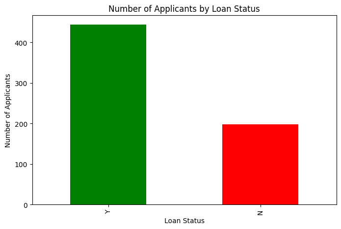

```python
# The total number of applicants broken down into Approved and Rejected
status_counts = full_data1['Loan_Status'].value_counts()  # Counts of each loan status
print("Number of applicants (Approved/Rejected):")
print(status_counts)

# Plotting the number of applicants by approval status
plt.figure(figsize=(8, 5))
status_counts.plot(kind='bar', color=['green', 'red'])
plt.title('Number of Applicants by Loan Status')
plt.xlabel('Loan Status')
plt.ylabel('Number of Applicants')
plt.show()
```

```
Number of males and females in each case (Approved and Rejected):
Loan_Status  Gender
N            1         161
             2          37
Y            1         364
             2          80
Name: Gender, dtype: int64
```

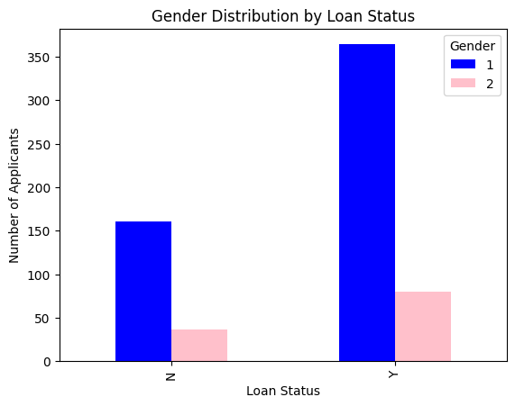

```python
# The number of males and females in each case (Approved and Rejected)
# Assuming 'Gender' coded as 0 for female and 1 for male
gender_status_counts = full_data1.groupby(['Loan_Status', 'Gender'])['Gender'].count()  # Group by 'Loan_Status' and 'Gender'
print("Number of males and females in each case (Approved and Rejected):")
print(gender_status_counts)

# Plotting the number of males and females in each case
plt.figure(figsize=(8, 5))
gender_status_counts.unstack().plot(kind='bar', color=['blue', 'pink'])
plt.title('Gender Distribution by Loan Status')
plt.xlabel('Loan Status')
plt.ylabel('Number of Applicants')
plt.show()
```

## 5. The maximum and minimum of amounts loaned and shown in an appropriate chart.

```
Maximum amount loaned: 700
Minimum amount loaned: 9
```

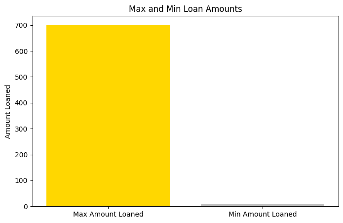

```python
# The maximum and minimum of amounts loaned
max_loan_amount = full_data1['LoanAmount'].max()  # Maximum of 'LoanAmount'
min_loan_amount = full_data1['LoanAmount'].min()  # Minimum of 'LoanAmount'
print("Maximum amount loaned:", max_loan_amount)
print("Minimum amount loaned:", min_loan_amount)

# Plotting max and min amounts loaned
plt.figure(figsize=(8, 5))
plt.bar(['Max Amount Loaned', 'Min Amount Loaned'], [max_loan_amount, min_loan_amount], color=['gold', 'silver'])
plt.title('Max and Min Loan Amounts')
plt.ylabel('Amount Loaned')
plt.show()
```

## 6. The number of self-employed who had their loan approved, expressed as a percentage of all who had their loan approved, and shown in an appropriate chart..

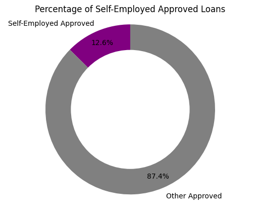

```python
# Filtering approved loans
approved_loans = full_data1[full_data1['Loan_Status'] == 'Y']

# Counting self-employed who got their loans approved
self_employed_approved = approved_loans[approved_loans['Self_Employed'] == 1].shape[0]

# Calculating the percentage of approved loans that went to self-employed individuals
total_approved = approved_loans.shape[0]
percentage_self_employed_approved = (self_employed_approved / total_approved) * 100

# Data for the donut chart
sizes = [percentage_self_employed_approved, 100 - percentage_self_employed_approved]
labels = ['Self-Employed Approved', 'Other Approved']
colors = ['purple', 'grey']

# Plotting the donut chart
fig, ax = plt.subplots()
ax.pie(sizes, labels=labels, colors=colors, autopct='%1.1f%%', startangle=90, pctdistance=0.85)
ax.axis('equal')  # Equal aspect ratio ensures that pie is drawn as a circle.

# Draw a circle at the center of pie to make it look like a donut
centre_circle = plt.Circle((0,0),0.70,fc='white')
fig.gca().add_artist(centre_circle)

plt.title('Percentage of Self-Employed Approved Loans')
plt.show()
```

## 7. The income distribution of all main applicants, showing average and standard deviation.

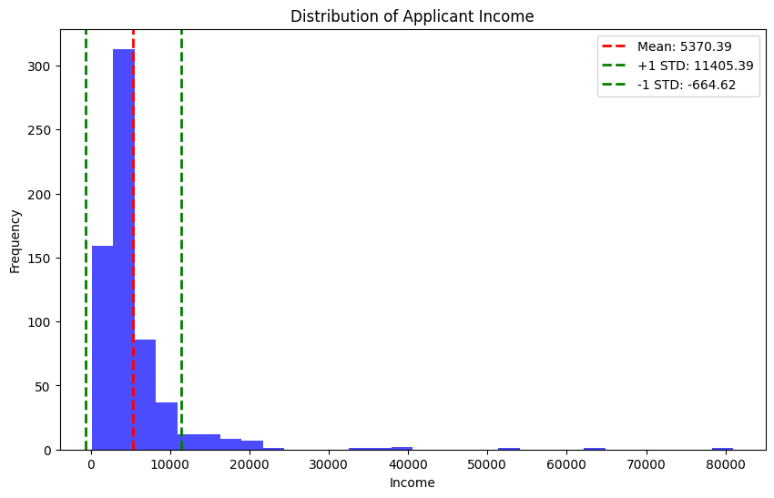

```python
# Calculating the mean and standard deviation of the ApplicantIncome
mean_income = full_data1['ApplicantIncome'].mean()
std_dev_income = full_data1['ApplicantIncome'].std()

# Plotting the income distribution
plt.figure(figsize=(10, 6))
plt.hist(full_data1['ApplicantIncome'], bins=30, color='blue', alpha=0.7)
plt.axvline(mean_income, color='red', linestyle='dashed', linewidth=2, label=f'Mean: {mean_income:.2f}')
plt.axvline(mean_income + std_dev_income, color='green', linestyle='dashed', linewidth=2, label=f'+1 STD: {mean_income + std_dev_income:.2f}')
plt.axvline(mean_income - std_dev_income, color='green', linestyle='dashed', linewidth=2, label=f'-1 STD: {mean_income - std_dev_income:.2f}')
plt.title('Distribution of Applicant Income')
plt.xlabel('Income')
plt.ylabel('Frequency')
plt.legend()
plt.show()
```

## 8. The top ten applicants by loan amount

```python
# Sorting the DataFrame by 'LoanAmount' in descending order and selecting the top 10
top_ten_applicants = full_data1.sort_values(by='LoanAmount', ascending=False).head(10)

# Printing the top ten applicants
print("Top Ten Applicants by Loan Amount:")
print(top_ten_applicants[['Loan_ID', 'ApplicantIncome', 'LoanAmount']])
```

```
Top Ten Applicants by Loan Amount:
     Loan_ID  ApplicantIncome  LoanAmount
171     1585            51763         700
130     1469            20166         650
155     1536            39999         600
194     2813            19484         600
369     2191            19730         570
120     2547            18333         500
237     2959            12000         496
177     1610             5516         495
333     2101            63337         490
139     2624            20833         480
```

## 9. The distribution of properties (rural, urban etc) of all loan applicants, shown in an appropriate chart.

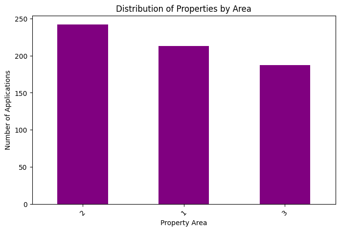

```python
# Counting occurrences of each property area type
property_area_distribution = full_data1['Property_Area'].value_counts()

# Plotting the distribution of property areas
plt.figure(figsize=(8, 5))
property_area_distribution.plot(kind='bar', color='purple')
plt.title('Distribution of Properties by Area')
plt.xlabel('Property Area')
plt.ylabel('Number of Applications')
plt.xticks(rotation=45)
plt.show()
```